# GENERALIZED LINEAR MODELS

#### 5. Checking the link function

Plot the working residuals against the linear predictor. If no pattern is discernable, we can ascertain the correct link function was used.

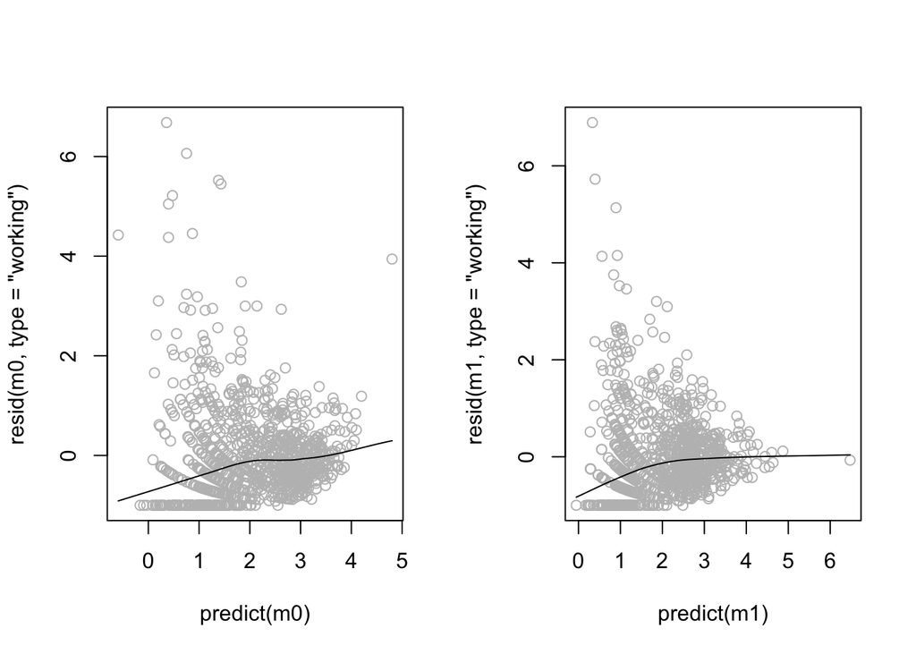

Interestingly, both models appear to have slight logarithmic relationship.

#### Outliers and influential observations

#### Cook’s Distance

Cook’s distance *Di* of observation *i(for i=1,…,n)* is defined as the sum of all the changes in the regression model when observation i is removed from it.  
Cook’s distance helps us find observations with high leverage:

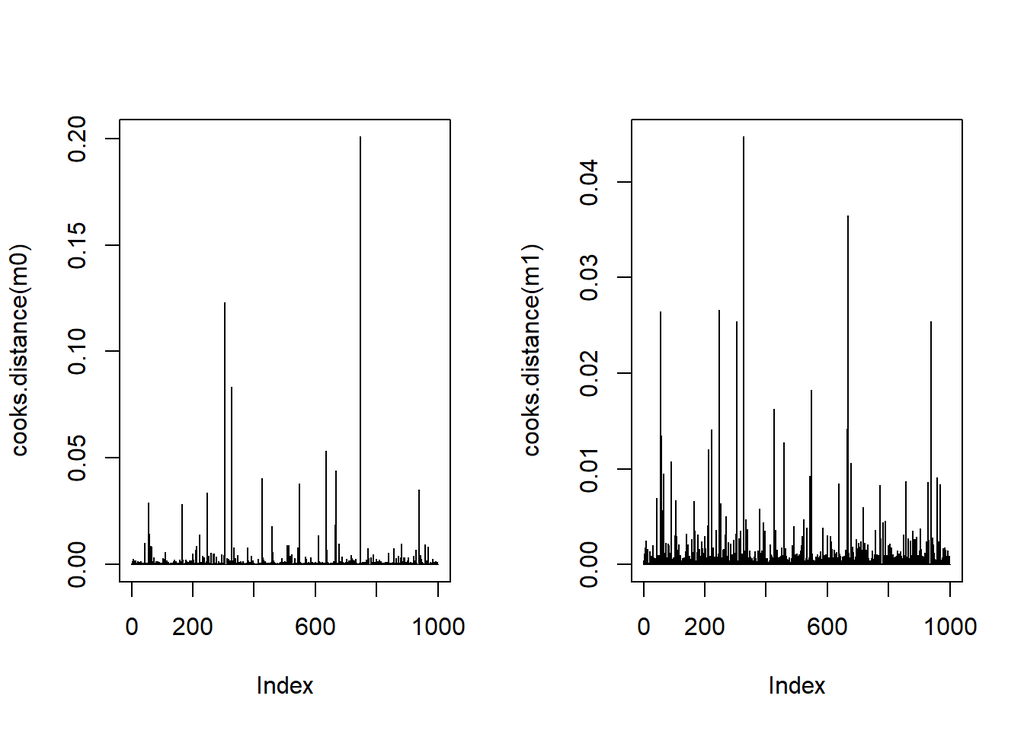

```r
par(mfrow=c(1,2))
plot(cooks.distance(m0), type='h')
plot(cooks.distance(m1), type='h')
```

The scale of the y-axis is much lower in M1 (on the right) than M0. We can further specify the specific points with high leverage using a benchmark of 2 times the mean of Cook’s distance:

```r
cooksd_m0 <- cooks.distance(m0)
cooksd_m1 <- cooks.distance(m1)

length(cooksd_m0[cooksd_m0 > mean(cooksd_m0) * 2])
```

```
## [1] 65
```

```r
length(cooksd_m1[cooksd_m1 > mean(cooksd_m1) * 2])
```

```
## [1] 96
```

Let’s examine an observation with a high leverage in both models:

```r
df[73,]
```

|  | y | x.1 | x.2 | x.3 |
| --- | --- | --- | --- | --- |
| 73 | 80 | 0.7473986 | 1 | 0 |